# Baker Creek Watershed MESH Model - Data Preparation

# List of updates to be made

- Replace the “Load the data” section to download the streamflow data directly from Hydat, rather than from a file that has been downloaded manually

#Introduction This code performs all the data preparation used in the MESH Baker Creek model.

The file folder structure is based on the MESH_Project_Baker_Creek repository stored here: https://github.com/MESH-Model/MESH_Project_Baker_Creek. However, the first section allows for setting the directories for the storage of each dataset.

# Load libraries

#Set the directories

```r
ESSD_met="../Data/Raw/ESSD_Baker_Creek_Data/HydrometeorologicalData"
GEMCaPAFolder="../Data/Raw/GEM_CaPA_Data"

#Full column names for consistent data format:
full_colnames <- read_csv("met_variable_names.csv")
full_colnames <- colnames(full_colnames)
```

# Put the data from various sources in the same format

*Formerly the script “Prepar_Driving_Data.R”*

For each data source: - Perform unit conversion to get the units to Pa, W/m2 - Ensure the timezone is MST - Calculate specific humidity

## Vital Tower

Prep the Vital data frame

```r
colnames_vital=c('Year', 'DateTime', 'AirP', 'Kin', 'Kout', 'Lin', 'Lout', 'Qstar', 'T_4.4m', 'RH_4.4m', 'T_2m', 'RH_2m', 'u_4.4m', 'Rain_mm', 'Qe', 'Qh')

Vital_load <- read_csv(file=paste0(ESSD_met,"/vital tower half hourly time series v1.csv"), col_names = colnames_vital, skip=1)
    #Units are: kPa, W/m2, degC, %, m/s, and mm; timezone is MST

#Change Vital_load to a CRHMr data frame (i.e. first column called "datetime" in Posixct)
Vital <- Vital_load
Vital <- select(Vital, -1)
Vital$DateTime <- dmy_hm(Vital$DateTime, tz="MST")
Vital <- as.data.frame(Vital)
Vital <- rename(Vital, datetime=DateTime, T.2=T_2m, T.1=T_4.4m, RH.2=RH_2m, RH.1=RH_4.4m)
  #1 is at 4.4m, #2 is at 2m
class(Vital$datetime)
```

```
[1] "POSIXct" "POSIXt"
```

```
POSIXct

POSIXt
```

```r
#Replace all "9999" values with "NA"
Vital[Vital==9999]<- NA
Vital[Vital==99999]<- NA
```

### Specific humidity calculation

```r
#Convert RH to ea using the CRHMr package
Vital <- changeRHtoEa(Vital, quiet=FALSE)
```

```
               summary
1   Time step (hours):
2          Total rows:
3       Complete rows:
4                From:
5                  To:
6 First complete date:
7  Last complete date:
8 Number of variables:
9      Variable names:
                                                                value
1                                                                 0.5
2                                                              205519
3                                                               64100
4                                                          2005-04-12
5                                                          2016-12-31
6                                                          2007-04-22
7                                                          2016-09-20
8                                                                  14
9 AirP Kin Kout Lin Lout Qstar T.1 ea.1 T.2 ea.2 u_4.4m Rain_mm Qe Qh
```

```r
  # Note: ea results are in kPa

# Convert ea to q using the humidity package
Vital <- mutate(Vital, q.1=SH(ea.1, AirP), q.2=SH(ea.2, AirP))
```

#### Check the RH to ea calculation

This section calculates the comparison between methods for calculating ea and q (this is not crucial to the data-prep process, but give some justification for the method chosen.)

```r
# # Using the CRHMr function "changeRHtoEa"
# Vital_ea_C <- changeRHtoEa(Vital, quiet=FALSE)
# Vital_ea_C <- filter(Vital_ea_C, datetime %in% c(as.POSIXct("2006-07-15 14:00:00", tz="MST"), as.POSIXct("2007-04-23 00:00:00", tz="MST")))
#
# # Using Dingman equaitons 3.9a, 3.9b, 3.11 (matches CRHMr calculation almost exactly)
# Vital_ea_D <- Vital
# Vital_ea_D <- Vital_ea_D %>%
#   filter(datetime %in% c(as.POSIXct("2006-07-15 14:00:00", tz="MST"), as.POSIXct("2007-04-23 00:00:00", tz="MST")))%>%
#  mutate(ea.1=ifelse(T.1>=0,RH.1/100*0.611*exp(17.27*T.1/(T.1+237.3)),RH.1/100*0.611*exp(21.87*T.1/(T.1+265.5))))%>%
#  mutate(ea.2=ifelse(T.2>=0,RH.2/100*0.611*exp(17.27*T.2/(T.2+237.3)),RH.2/100*0.611*exp(21.87*T.2/(T.2+265.5))))
#
# #Using the formula on the Wiki (doesn't match the CRHMr calculation)
# Vital_ea_W <- Vital
# Vital_ea_W <- Vital_ea_W %>%
#   filter(datetime %in% c(as.POSIXct("2006-07-15 14:00:00", tz="MST"), as.POSIXct("2007-04-23 00:00:00", tz="MST")))%>%
#    mutate(ea.1=RH.1/100*10^((0.7859+0.03477*T.1)/(1.0+0.00412*T.1)+2)/1000)%>%
#    mutate(ea.2=RH.2/100*10^((0.7859+0.03477*T.2)/(1.0+0.00412*T.2)+2)/1000)
#
# # Using the humidity package
# Vital_ea_hum <- Vital
# Vital_ea_hum <- Vital_ea_hum %>%
#     filter(datetime %in% c(as.POSIXct("2006-07-15 14:00:00", tz="MST"), as.POSIXct("2007-04-23 00:00:00", tz="MST"))) %>%
#   mutate(es.1=SVP(C2K(T.1)), es.2=SVP(C2K(T.2))) %>%
#   mutate(ea.1=WVP2(RH.1, es.1)/1000, ea.2=WVP2(RH.2, es.2)/1000)
```

CONCLUSION: The calculaiton of ea from T and RH differs from the Wiki to the humidity package to CRHMr/Dingman (note: CRHMr and Dingman get the same answer for both >0oC and <0oC). In general, the Wiki calc is slightly larger for >0oC and larger for <0oC, whereas the humidity package is larger for both above and below 0oC. Since we are working in a cold climate, use the CRHMr package.

#### Check the ea to q calculation

```r
# # Use the ea calculation from the CRHMr package (Vital_ea_C)
#
# # Using the humidity package:
# qcheck_hum <- Vital_ea_C
# qcheck_hum <- qcheck_hum %>%
#   filter(datetime %in% c(as.POSIXct("2006-07-15 14:00:00", tz="MST"), as.POSIXct("2007-04-23 00:00:00", tz="MST")))%>%
#   mutate(q.1=SH(ea.1, AirP), q.2=SH(ea.2, AirP))
#
# # Using the Dingman Calculation
#
# qcheck_D <- filter(Vital_ea_C, datetime %in% c(as.POSIXct("2006-07-15 14:00:00", tz="MST"), as.POSIXct("2007-04-23 00:00:00", tz="MST")))
# qcheck_D <- qcheck_D %>%
#   mutate(q.1=0.622*ea.1/AirP, q.2=0.622*ea.2/AirP)
#
# # Using the Wiki Calculation
#
# qcheck_W <- Vital_ea_C
# qcheck_W <- qcheck_W %>%
#   select(-q.1, -q.2)%>%
#   filter(datetime %in% c(as.POSIXct("2006-07-15 14:00:00", tz="MST"), as.POSIXct("2007-04-23 00:00:00", tz="MST")))%>%
#   mutate(q.1=0.622*ea.1/(AirP-0.378*ea.1), q.2=0.622*ea.2/(AirP-0.378*ea.2))
```

CONCLUSION: All the methods, when using the same ea and AirP input, give the same q result. Therefore going forward, will use the humidity package funciton “SH”

### Put the data into the standard format

```r
# Convert air pressure to Pa and put in a new column called "AirP_Pa"
Vital <- mutate(Vital, AirP_Pa=AirP*1000)

# Rename columns to match the standard format
Vital <- rename(Vital, T_4.4m=T.1, T_2m=T.2, q_4.4m=q.1, q_2m=q.2, DateTime=datetime)

#Remove unneeded columns (AirP, ea)
Vital <-  select(Vital, -c(AirP,ea.1, ea.2))

#Add missing columns and re-order columns

Vital_cols <- colnames(Vital)
missing_colnames <- setdiff(full_colnames,Vital_cols)
Vital[,missing_colnames] <- NA
Vital$Station <- "Vital"
Vital <- Vital[, full_colnames]

save(Vital, file="Vital.Rda", version=2)

#qplot(data=Vital,x=DateTime, y=T_4.4m, geom='point')
#qplot(data=Vital,x=DateTime, y=AirP_Pa, geom='point')
```

## Landing Tower

Prep the Landing data frame

```r
colnames_landing=c('DateTime', 'u_1.1m', 'u_dir', 'T_1.1m', 'ea_1.1m', 'Qstar', 'Kin', 'Kout', 'Twater', 'Qe', 'Qh')

Landing_load <- read_csv(file=paste0(ESSD_met,"/landing tower half hourly time series v1.csv"),col_names=colnames_landing, skip=1)
    #Units are: kPa, W/m2, degC, %, m/s, and mm; Actual meas. height of T and e is 1.4 m; labelled as 1.1m for simplification with other datasets

Landing <- Landing_load
Landing$DateTime <- dmy_hm(Landing$DateTime, tz="MST")
Landing <- as.data.frame(Landing)
#Landing <- rename(Landing, datetime=DateTime, T.2=T_2m, T.1=T_4.4m, RH.2=RH_2m, RH.1=RH_4.4m)
  #1 is at 4.4m, #2 is at 2m
class(Landing$DateTime)
```

```
[1] "POSIXct" "POSIXt"
```

```
POSIXct

POSIXt
```

```r
#Replace all "9999" values with "NA"
Landing[Landing==9999]<- NA
```

### Specific humidity calculation

- Since no air pressure measurement for the Landing Tower, use the air pressure measurement from Vital station

```r
Vital_AirP <- tibble(DateTime=Vital$DateTime, Vital_AirP_Pa=Vital$AirP_Pa)
Vital_AirP <- as.data.frame(Vital_AirP)
Landing <- merge(x=Landing,y=Vital_AirP, by="DateTime", all=TRUE)

# Convert ea to q using the humidity package
Landing <- mutate(Landing, q_1.1m=SH(ea_1.1m, Vital_AirP_Pa))
```

### Put the data into the standard format

```r
#Remove unneeded columns (used for intermediate calculation)
Landing <- Landing %>% select(-c(u_dir,Twater,Vital_AirP_Pa, ea_1.1m))

#Add missing columns and re-order columns
Landing_cols <- colnames(Landing)
missing_colnames <- setdiff(full_colnames,Landing_cols)
Landing[,missing_colnames] <- NA
Landing$Station <- "Landing"
Landing <- Landing[, full_colnames]

#Remove rows that are all NA
#Landing <- Landing[rowSums(is.na(Landing))!= ncol(Landing)-2,]
    # Note: didn't do this for Vital either (for now)

save(Landing, file="Landing.Rda", version=2)
```

## GEM Data

Load the data files and combine into 1 *Note: GEMLanding and GEMVital are the same values (same GEM grid); Therefore, dropped the GEMLanding data*

```r
GEMFiles <- list.files(path=GEMCaPAFolder, pattern=glob2rx("rdps*.csv"))

file_names <- c("Lin", "AirP_Pa", "Kin", "q_2m", "q_40m", "T_2m_degC","T_2m_degK","T_40m_degC", "T_40m_degK", "u_10m", "u_40m")
    #Units: W/m2, Pa, kg/kg, degrees C, degrees K, m/s; no need to do conversions

i=1
colNames_GEM=c("DateTime", "GEMYellowknifeA", "GEMLanding", "GEMVital")
for(x in GEMFiles) {
  assign(file_names[i],as.data.frame(read_csv(paste0(GEMCaPAFolder,"/",x),skip=3,col_names=colNames_GEM)))  #Read the file and assign name
  i=i+1
}
```

### Convert the hourly GEM data to half-hourly

```r
#Change the hourly GEM timeseries to halfhourly using the user-defined function "oneToHalfHr"
      # If you want to assign values to the half hour by interpolating, pass interpolate=1,otherwise interpolate=0 will assign the hour value to the following half hour

      #This block of code was for testing purposes
      #Lin_test <- Lin
      #Lin_test <- filter(Lin_test, DateTime <= "2005-05-18 17:00:00")
          ### Note: this is returning the last value at 2005-05-18 23:00:00, which is UTC+6

oneToHalfHr <- function(myData, interpolate=1) {
    p <- hms::as_hms(60*30) #30 minutes
  HalfHourly <- myData
  if (interpolate == 1) {
    HalfHourly[,1] <- HalfHourly[,1] - p
    for (i in 2:ncol(myData)){
      HalfHourly[,i] <- rollmean(myData[,i], 2, align="right", fill=NA)
    }
    HalfHourly <- HalfHourly[-1,]
  } else {
    HalfHourly[,1] <- HalfHourly[,1] + p
  }
  myData <- rbind(myData, HalfHourly)
  myData <- arrange(myData,DateTime)
}

#rm(T_2m_degK, T_40m_degK)

i=1
for (x in file_names) {
  assign(paste0(file_names[i],"30min"),oneToHalfHr(eval(parse(text=file_names[i])),1))
  i=i+1
}
#The above loop does the same as below for all variables
#Lin30min <- oneToHalfHr(Lin,1)

#Test if the average is preserved
ChkAvgPreserve <- function(variable1, variable2){
  ColNames <- colnames(variable1)
  Avg_check <- summarise_each(variable1, fun=mean, ColNames[-1])
  Avg_check[2,] <- summarise_each(variable2, fun=mean, ColNames[-1])
  Avg_check[3,] <- summarise_each(Avg_check, fun=diff, ColNames[-1])
  Avg_check$DataMean <- c("Original", "30 min", "Difference")
  assign(paste0("AvgPreserve_", deparse(substitute(variable1))), Avg_check, envir=.GlobalEnv)
}

ChkAvgPreserve(u_10m, u_10m30min)
```

### Combine all GEM data into one data frame

*Note: Only preserving temperature values in degC -> will convert all temps. after

```r
#Gather and combine all the datasets; couldn't figure out how to do this in a loop

#First, create the Dataset
Lin30min <- Lin30min %>%
  select(-GEMLanding)%>%
  gather('GEMYellowknifeA', 'GEMVital', key="Station", value='Lin')
GEM_data <- Lin30min

      #Then gather each value and add to the combined dataset, GEM_data
AirP_Pa30min <- AirP_Pa30min %>%
  select(-GEMLanding)%>%
  gather('GEMYellowknifeA', 'GEMVital', key="Station", value='AirP_Pa')
GEM_data <- merge(x=GEM_data, y=AirP_Pa30min, by=c("DateTime","Station"), all=TRUE)

Kin30min <- Kin30min %>%
  select(-GEMLanding)%>%
  gather('GEMYellowknifeA', 'GEMVital', key="Station", value='Kin')
GEM_data <- merge(x=GEM_data, y=Kin30min, by=c("DateTime","Station"), all=TRUE)

q_2m30min <- q_2m30min %>%
  select(-GEMLanding)%>%
  gather('GEMYellowknifeA', 'GEMVital', key="Station", value='q_2m')
GEM_data <- merge(x=GEM_data, y=q_2m30min, by=c("DateTime","Station"), all=TRUE)

q_40m30min <- q_40m30min %>%
  select(-GEMLanding)%>%
  gather('GEMYellowknifeA', 'GEMVital', key="Station", value='q_40m')
GEM_data <- merge(x=GEM_data, y=q_40m30min, by=c("DateTime","Station"), all=TRUE)

T_2m_degC30min <- T_2m_degC30min %>%
  select(-GEMLanding)%>%
  gather('GEMYellowknifeA', 'GEMVital', key="Station", value='T_2m_degC')
GEM_data <- merge(x=GEM_data, y=T_2m_degC30min, by=c("DateTime","Station"), all=TRUE)

T_40m_degC30min <- T_40m_degC30min %>%
  select(-GEMLanding)%>%
  gather('GEMYellowknifeA', 'GEMVital', key="Station", value='T_40m_degC')
GEM_data <- merge(x=GEM_data, y=T_40m_degC30min, by=c("DateTime","Station"), all=TRUE)

u_10m30min <- u_10m30min %>%
  select(-GEMLanding)%>%
  gather('GEMYellowknifeA', 'GEMVital', key="Station", value='u_10m')
GEM_data <- merge(x=GEM_data, y=u_10m30min, by=c("DateTime","Station"), all=TRUE)

u_40m30min <- u_40m30min %>%
  select(-GEMLanding)%>%
  gather('GEMYellowknifeA', 'GEMVital', key="Station", value='u_40m')
GEM_data <- merge(x=GEM_data, y=u_40m30min, by=c("DateTime","Station"), all=TRUE)

#Not including T_2m_degK or T_40m_degK -> will convert all temps to K later
```

### Convert timezone from UTC to MST

```r
#Convert the GEM data to Local time in Yellowknife (MST)
attr(GEM_data$DateTime, "tzone") <- "MST"
```

### Put the data into the standard format

```r
#Rename Temp Columns
GEM_data <- rename(GEM_data, T_40m=T_40m_degC, T_2m=T_2m_degC)

#Add missing columns and rearrange to match other datasets
GEM_cols <- colnames(GEM_data)
missing_colnames <- setdiff(full_colnames,GEM_cols)
GEM_data[,missing_colnames] <- NA

GEM_data <- GEM_data[, full_colnames]

save(GEM_data, file="GEM_data.Rda", version=2)
```

## CaPA Data

```r
# Load the data
colNames_CAPA=c("DateTime", "CAPAYellowknifeA", "CAPALanding", "CAPAVital")
CAPA_load <- read_csv(paste0(GEMCaPAFolder,"/rdpa_rain_nearest_20020101_20190101.csv"),skip=3,col_names=colNames_CAPA)
```

### Change the timezone and filter CaPA to exclue pre-2004 data

```r
Capa <- as.data.frame(CAPA_load)
attr(Capa$DateTime, "tzone") <- "MST" # Shifts the timezone from UTC to MST

Capa <- filter(Capa, year(DateTime)>=2004)
```

### Change the CAPA 6 hr timeseries into 1/2 hour timeseries and backfill the values of precip rate

#### Test out the CRHMr function “distributeP”

```r
#view(Capa)
CapaTest <- Capa %>%
  rename(datetime=DateTime)%>%
  select(datetime, CAPAVital)%>%
  mutate(P_tot=CAPAVital*60*60*6)%>%
  select(-CAPAVital)
class(CapaTest$datetime)

CapaDistP <- distributeP(CapaTest, p.cols=1, timestep=0.5)
CapaDistP[1,1]

#Compare the monthly totals (remove the "month" row and month from group_by for annual totals)
CapaTotal <- Capa %>%
  select(DateTime, CAPAVital)%>%
  mutate(P_acc=CAPAVital*60*60*6)%>%
  mutate(year=year(DateTime))%>%
  mutate(month=month(DateTime))%>%
  group_by(year, month)%>%
  summarise(P=sum(P_acc))

CapaDistTotal <- CapaDistP %>%
  mutate(year=year(datetime))%>%
  mutate(month=month(datetime))%>%
  group_by(year, month)%>%
  summarise(DistP=sum(P_tot))%>%
  filter(year>2003)

CapaTotal$DistP <- CapaDistTotal$DistP
CapaTotal <- mutate(CapaTotal, Diff=DistP-P)


# Compare CapaDistP with the Capa30min I generated
CapaCompare <- CapaDistP %>%
  rename(DateTime=datetime)

Capa30min2 <- filter(Capa30min, Station=="CAPAVital")

CapaCompare <- merge(x=CapaCompare, y=Capa30min2, by="DateTime", all=TRUE)

CapaCompare2 <- CapaCompare %>%
  rename(DistP=P_tot, VitalOrig=Precip_rate)%>%
  mutate(VitalOrig=VitalOrig*60*30)%>%
  select(-Station)%>%
  gather(DistP, VitalOrig, key="Station", value="Amount")%>%
  mutate(Date=date(DateTime))%>%
  group_by(Date, Station)%>%
  summarise(DailySum=sum(Amount))

CapaCompare2$CommonDate <- as.Date(paste0("2001-", format(CapaCompare2$Date, "%j")),"%Y-%j")

PrecipCompare0511 <- filter(CapaCompare2, year(Date) %in% 2005:2011)
ggplot() +
  geom_line(data=PrecipCompare0511, mapping=aes(x=CommonDate, y=DailySum, color=Station), size=0.5) +
  facet_grid(year(PrecipCompare0511$Date) ~ .) +
  scale_x_date(labels=function(x) format(x,"%d-%b")) +
  labs(title="Daily Precip - 2005-2011 (check)")

PrecipCompare1218 <- filter(CapaCompare2, year(Date) %in% 2012:2018)
ggplot() +
  geom_line(data=PrecipCompare1218, mapping=aes(x=CommonDate, y=DailySum, color=Station), size=0.5) +
  facet_grid(year(PrecipCompare1218$Date) ~ .) +
  scale_x_date(labels=function(x) format(x,"%d-%b")) +
  labs(title="Daily Precip - 2012-2018 (check)")

AnnualSums <- CapaCompare %>%
  rename(DistP=P_tot, VitalOrig=Precip_rate)%>%
  mutate(VitalOrig=VitalOrig*60*30)%>%
  select(-Station)%>%
  gather(DistP, VitalOrig, key="Station", value="Amount")%>%
  mutate(year=year(DateTime))%>%
  group_by(year, Station)%>%
  summarise(AnnualSum=sum(Amount))
```

```r
load("./Capa30min.Rda")

# This function takes a long time to run (may 10 ish minutes?) but it works. Need to find a quicker solution.
# Maybe this?? https://gist.github.com/dsparks/3706541

  #Obtain the start time as 11x 30 min timesteps prior to the first observation
# startCapa30min <- as.POSIXlt(Capa$DateTime[1]) # Obtain the start time of the dataset
# startCapa30min$min <- startCapa30min$min-(30*11) #Adjust the start time of the 30 min dataset to be 5.5 hours earlier(11x 30min timesteps)
# startCapa30min
#
# Capa[nrow(Capa),1]
# Capa30min[nrow(Capa30min),1]
#
#
#   #Initialzie the DateTime column with the 30 min timesteps desired
# Capa30min <- seq(as.POSIXct(startCapa30min, tz="MST"), Capa$DateTime[nrow(Capa)], by=(60*30)) # by is seconds
# Capa30min <- as.data.frame(Capa30min)
# Capa30min <- rename(Capa30min, DateTime=Capa30min)
#
# # Capa30min_check <- Capa30min %>%
# #   rename(datetime=DateTime)
# #
# # findDupes(Capa30min_check)
#
# Capa30min$CAPAYellowknifeA <- NA
# Capa30min$CAPALanding <- NA
# Capa30min$CAPAVital <- NA
#
#   #Apply the rainfall rate from the Capa data to 12 timesteps in the 30min dataframe
# Capa30minRow=1
# CapaRow=1
# numit=nrow(Capa30min)/12
# for (i in 1:numit){
#   for (j in 1:12){
#     Capa30min[Capa30minRow,2] <- Capa[CapaRow,2]
#     Capa30min[Capa30minRow,3] <- Capa[CapaRow,3]
#     Capa30min[Capa30minRow,4] <- Capa[CapaRow,4]
#     Capa30minRow=Capa30minRow+1
#   }
#   CapaRow=CapaRow+1
# }
#
# Capa30min_made <- Capa30min
#
# findDupes(Capa30min)
#
# Capa30min <- gather (Capa30min, 'CAPAYellowknifeA', 'CAPALanding', 'CAPAVital', key="Station", value='Precip_rate')
#
save(Capa30min, file='Capa30min.Rda', version=2)

head(Capa30min)
```

|  | DateTime | CAPAYellowknifeA | CAPALanding | CAPAVital |
| --- | --- | --- | --- | --- |
| 1 | 2003-12-31 23:30:00 | 2.975556e-06 | 4.234357e-06 | 4.234357e-06 |
| 2 | 2004-01-01 00:00:00 | 2.975556e-06 | 4.234357e-06 | 4.234357e-06 |
| 3 | 2004-01-01 00:30:00 | 2.975556e-06 | 4.234357e-06 | 4.234357e-06 |
| 4 | 2004-01-01 01:00:00 | 2.975556e-06 | 4.234357e-06 | 4.234357e-06 |
| 5 | 2004-01-01 01:30:00 | 2.975556e-06 | 4.234357e-06 | 4.234357e-06 |
| 6 | 2004-01-01 02:00:00 | 2.975556e-06 | 4.234357e-06 | 4.234357e-06 |

```r
summary(Capa30min)
```

```
    DateTime                   CAPAYellowknifeA     CAPALanding
 Min.   :2003-12-31 23:30:00   Min.   :0.000e+00   Min.   :0.000e+00
 1st Qu.:2007-10-01 14:22:30   1st Qu.:0.000e+00   1st Qu.:0.000e+00
 Median :2011-07-02 05:15:00   Median :6.580e-08   Median :3.850e-07
 Mean   :2011-07-02 05:15:00   Mean   :1.015e-05   Mean   :1.092e-05
 3rd Qu.:2015-04-01 20:07:30   3rd Qu.:4.003e-06   3rd Qu.:5.941e-06
 Max.   :2018-12-31 11:00:00   Max.   :1.314e-03   Max.   :8.970e-04
   CAPAVital
 Min.   :0.000e+00
 1st Qu.:0.000e+00
 Median :4.537e-07
 Mean   :1.101e-05
 3rd Qu.:6.226e-06
 Max.   :8.970e-04
```

```r
glimpse(Capa30min)
```

```
Observations: 262,968
Variables: 4
$ DateTime         <dttm> 2003-12-31 23:30:00, 2004-01-01 00:00:00, 2004…
$ CAPAYellowknifeA <dbl> 2.975556e-06, 2.975556e-06, 2.975556e-06, 2.975…
$ CAPALanding      <dbl> 4.234357e-06, 4.234357e-06, 4.234357e-06, 4.234…
$ CAPAVital        <dbl> 4.234357e-06, 4.234357e-06, 4.234357e-06, 4.234…
```

## Yellowknife Data

Measurement heights for Yellowknife data assumed to be 2 m for all measurements except wind, which is 10 m

```r
# If data is already loaded and saved
load("./yknife_hr.Rda")

# # If data needs to be downloaded and processed
# stations_search("Yellowknife", interval=c("hour", "day"))
#
# y1706_hr <- weather_dl(station_id = 1706,start="2004-01-01", end="2019-01-01", interval="hour", time_disp="UTC")
# y51058_hr <- weather_dl(station_id = 51058 ,start="2004-01-01", end="2019-01-01", interval="hour", time_disp="UTC")
#
# #Combine the hourly data from the different station numbers into one
# yknife_all_hr <- rbind(y1706_hr,y51058_hr)
#
# #Change the yellowknife data to a data frame
# yknife_all_hr <- as.data.frame(yknife_all_hr)
#
# yknife_all_hr$time[1]
#
# #Change the timezeon to MST from UTC (downloaded in UTC explicitly)
# attr(yknife_all_hr$time, "tzone") <- "MST"
#
#
# #Save the data
# save(yknife_all_hr,file="yknife_hr.Rda", version=2)
```

### Calculations / Converstions

```r
#Rename and select relevant columns (note: column names temporary for use with CRHMr)

yknife <- yknife_all_hr %>%
  rename(datetime=time, AirP=pressure, rh.1=rel_hum, t.1=temp, u_10m=wind_spd) %>%
  select(datetime, t.1, u_10m, AirP, rh.1)

#Convert RH to ea using the CRHMr package
yknife <-  changeRHtoEa(yknife, quiet=FALSE)
```

```
               summary               value
1   Time step (hours):                   1
2          Total rows:              131585
3       Complete rows:              131426
4                From:          2004-01-01
5                  To:          2019-01-01
6 First complete date:          2004-01-01
7  Last complete date:          2019-01-01
8 Number of variables:                   4
9      Variable names: t.1 u_10m AirP ea.1
```

```r
  # Note: ea results are in kPa

# Convert ea to q using the humidity package
yknife <- mutate(yknife, q.1=SH(ea.1, AirP))

# Convert AirP to Pa from kPa, and convert wind from km/h to m/s, rename columns

yknife <- yknife %>%
  mutate(AirP_Pa = AirP*1000, u_10m=u_10m/3.6)%>%
  rename(DateTime=datetime, T_2m=t.1, q_2m=q.1)%>%
  select(-ea.1, -AirP)

#Convert Yellowknife Data to Half Hourly using interpolation between the hourly points
# Use the "OnetoHalfHr" function defined above
yknife_30min <- oneToHalfHr(yknife, 1)

class(yknife_30min[2,1])
```

```
[1] "POSIXct" "POSIXt"
```

```
POSIXct

POSIXt
```

```r
yknife_30min[1,1]
```

```
[1] "2004-01-01 MST"
```

```r
Yknife <- yknife_30min
Yknife$Station <- "YellowknifeA"
```

### Put the data into the standard format

```r
Yknife_cols <- colnames(Yknife)
missing_colnames <- setdiff(full_colnames,Yknife_cols)
Yknife[,missing_colnames] <- NA

Yknife <- Yknife[, full_colnames]

# Save the tidied Yellowknife Data
save(Yknife,file="Yknife_HalfHr.Rda", version=2)
```

# Prepare Streamflow Data for the MESH Model

Streamflow data was obtained from the Water Survey of Canada website for station 07SB013 Baker Creek at the Outlet of Lower Martin Lake WSC - 07SB013

## Loading in the data

```r
# Download the HYDAT database (if not already done so; takes about 10 mins)

# hy_dir() # Returns the location of the Hydat database directory
# download_hydat() # Downloads the hydat database; have to type a response (yes or no) and won't download again if you have the most recent version
#
# Qload <- hy_daily_flows("07SB013", start_date="2005-01-01", end_date="2019-12-31")
# Qload <- as.data.frame(Qload)
# head(Qload)
# summary(Qload)
#
# save(Qload, file="Qload.Rda", version=2)


load("./Qload.Rda")
```

## Using CRHMr to explore the missing values in the data

```r
Q <- Qload
Q <- Q %>%
  select(-Parameter, -STATION_NUMBER, -Symbol)%>%
  rename(datetime=Date, Flow=Value)

# Add a time (used noon) for the daily flow values for use with POSIXct format
hour(Q$datetime) <- 12
Q$datetime <- force_tz(Q$datetime, tz="MST")
Q$datetime[1]
```

```
[1] "2005-01-01 12:00:00 MST"
```

```r
Q$datetime <- as.POSIXct(Q$datetime)
class(Q$datetime)
```

```
[1] "POSIXct" "POSIXt"
```

```
POSIXct

POSIXt
```

```r
# Find and explore gaps in the data
findGaps(Q, minlength=1, quiet=FALSE) #Stores the gap details in a file called "Qgaps.csv")
```

```
No gaps in datetimes
  variable year gaps total.length
1     Flow 2013    2           19
```

```
[1] TRUE
```

```r
Qna <- filter(Q, is.na(Flow)==TRUE)
    # Any existing gaps were already "NA" values

# Replace NA valuses with -9999
Qfull <- Q
Qfull$Flow[is.na(Qfull$Flow)==TRUE] <- -9999
summary(Qfull)
```

```
    datetime                        Flow
 Min.   :2005-01-01 12:00:00   Min.   :-9999.000
 1st Qu.:2008-04-02 06:00:00   1st Qu.:    0.000
 Median :2011-07-03 00:00:00   Median :    0.044
 Mean   :2011-07-03 00:00:00   Mean   :  -39.781
 3rd Qu.:2014-10-01 18:00:00   3rd Qu.:    0.228
 Max.   :2017-12-31 12:00:00   Max.   :    4.840
```

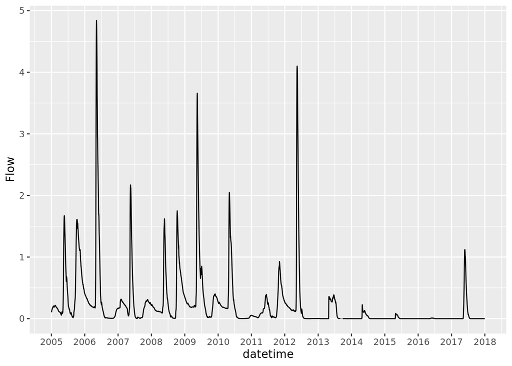

```r
# findGaps(Qfull, minlength=1, quiet=FALSE)

# Change the format and name of datetime back to "Date
# Qfull <- Qfull %>%
#   mutate(Date=as.Date(datetime))%>%
#   select(-datetime)
# Qfull <- Qfull[, c("Date", "Flow")]

# Plot the data (Note: Q still has missing values as "NA" rather than -9999, so better for plotting)
QPlot <- Q
QPlot$datetime <- as.Date(QPlot$datetime)

ggplot(data=QPlot, mapping=aes(x=datetime))+
  geom_line(aes(y=Flow)) +
  scale_x_date(date_labels=("%Y"), date_breaks=("years"))
```

## Separate the streamflow into calibration and validation periods and save them as .csv files

The model starts on September 15, 2006 (day 258), so will choose the calibration periods to also start on Sept. 15 (day 258) and end on Sept. 14 (day 257).

Spin-up period: of 2006-258 through 2007-257.

Calibration period: 2007-258 through 2010-257, and 2013-258 to 2015-257 (inclusive; start Sept. 15 and end Sept. 14)

Validation period: remainder of the modelled period, i.e. 2010-258 to 2013-257, and 2015-258 to 2016-258

```r
# Qfull is the complete, original streamflow dataset, filtered to start at 2005-01-01 and to replace missing values with -9999

# Create Qcal which contains only the measured flow during the calibration period
Qcal1 <- Qfull
Qcal1 <- filter(Qcal1, datetime>="2007-09-15" & datetime<="2010-09-14")
summary(Qcal1)
```

```
    datetime                        Flow
 Min.   :2007-09-15 12:00:00   Min.   :0.0010
 1st Qu.:2008-06-15 00:00:00   1st Qu.:0.1190
 Median :2009-03-15 12:00:00   Median :0.2080
 Mean   :2009-03-15 12:00:00   Mean   :0.3875
 3rd Qu.:2009-12-14 00:00:00   3rd Qu.:0.3770
 Max.   :2010-09-13 12:00:00   Max.   :3.6600
```

```r
Qcal2 <- Qfull
Qcal2 <- filter(Qcal2, datetime >= "2013-09-15" & datetime <= "2015-09-14")

Qcal <- rbind(Qcal1, Qcal2)
Qcal <- rename(Qcal, CalFlow=Flow)


# Create Qval which contains only the measured flow during the validation period
Qval1 <- Qfull
Qval1 <- filter(Qval1, datetime>="2010-09-15" & datetime<="2013-09-14")

Qval2 <- Qfull
Qval2 <- filter(Qval2, datetime >= "2015-09-15" & datetime <= "2016-09-14")

Qval <- rbind(Qval1, Qval2)
Qval <- rename(Qval, ValFlow=Flow)

# Create the "negative" flow, which changes the sign of flows > 0, and represents missing and zero flows with -9999
Qneg <- mutate(Qfull, Negative=ifelse(Flow==0|Flow==-9999,-9999,-1*Flow))

Qneg_check <- filter(Qneg, Negative==-9999)

Qneg <- select(Qneg, datetime, Negative)

# Put the negative, calibration, and validation flows together into one dataframe
Qboth <- merge(Qneg, Qcal,by="datetime", all=TRUE )
Qboth <- merge(Qboth, Qval, by="datetime", all=TRUE)

# This section populates the CalAll and ValAll columns with the flow values (actual or -ve values) for the whole timeperiod.
Qboth$CalAll <- NA
Qboth$ValAll <- NA

#First, puts the calibration period flows into the CalAll column. Then, pastes negative streamflow into the missing (NA) points. Then does the same for the ValAll column.
Qboth$CalAll <- Qboth$CalFlow
Qboth$CalAll[is.na(Qboth$CalAll)] <- paste0(Qboth$Negative[is.na(Qboth$CalAll)])
Qboth$CalAll <- as.double(Qboth$CalAll)
Qboth$ValAll <- Qboth$ValFlow
Qboth$ValAll[is.na(Qboth$ValAll)] <- paste0(Qboth$Negative[is.na(Qboth$ValAll)])
Qboth$ValAll <- as.double(Qboth$ValAll)

# Note one last thing: the model needs a positive value on the start date of the model. Therefore, change the streamflow value on 2006-09-15 to a positive value

ModelStart <- which(Qboth$Date==as.Date("2006-09-15")) #Returns the line where date=2006=09-15

Qboth$CalAll[ModelStart] <- -1*Qboth$CalAll[ModelStart]
Qboth$ValAll[ModelStart] <- -1*Qboth$ValAll[ModelStart]

# Check for missing values one final time
QCheckGaps <- Qboth %>%
  select(datetime, CalAll, ValAll)
findGaps(QCheckGaps)
```

```
No missing values in dataset
```

```
[1] FALSE
```

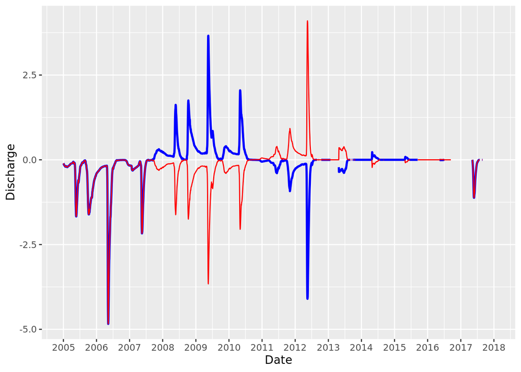

```r
#Plot the flow values to check to make sure the cal/val periods are right, and negative flows are represented.
    # Note: first need to change all -9999 values to NA so it doesn't throw off the plot

QPlot <- Qboth
QPlot <- mutate(QPlot, CalAll=ifelse(CalAll==-9999,NA,CalAll), ValAll=ifelse(ValAll==-9999,NA,ValAll))
QPlot$datetime <- as.Date(QPlot$datetime)

ggplot(data=QPlot, mapping=aes(x=datetime))+
  geom_line(aes(y=CalAll), color="blue", size=1) +
  scale_x_date(date_labels=("%Y"), date_breaks=("years")) +
  geom_line(aes(y=ValAll), color="red", size=0.5)+
  labs(x="Date", y="Discharge")
```

```r
#Check that the morphed dataset is the same as the original Q dataset
Qcheck <- Qfull
Qcheck$Check <- NA
Qcheck$Check <- abs(QPlot$CalAll)-Qcheck$Flow
CalCheck <- force(unique(Qcheck$Check))
CalCheck
```

```
[1]  0 NA
```

```r
Qcheck$Check <- abs(QPlot$ValAll)-Qcheck$Flow
ValCheck <- force(unique(Qcheck$Check))
ValCheck
```

```
[1]  0 NA
```

## Write the streamflow values to file - both an excel .csv file including the date, and a .csv file with only the flow values

```r
QFinal <- select(Qfull, datetime, Flow)
QWrite <- select(Qfull, Flow)
write_excel_csv(QFinal, "../Data/Processed/Validation/Streamflow_full.xlsx.csv")
write_tsv(QWrite, "../Data/Processed/Validation/Streamflow_full.csv", col_names=FALSE)

QFinal <- select(Qboth, datetime, CalAll)
QWrite <- select(Qboth, CalAll)
write_excel_csv(QFinal, "../Data/Processed/Validation/Streamflow_cal.xlsx.csv")
write_tsv(QWrite, "../Data/Processed/Validation/Streamflow_cal.csv", col_names=FALSE)

QFinal <- select(Qboth, datetime, ValAll)
QWrite <- select(Qboth, ValAll)
write_excel_csv(QFinal, "../Data/Processed/Validation/Streamflow_val.xlsx.csv")
write_tsv(QWrite, "../Data/Processed/Validation/Streamflow_val.csv", col_names=FALSE)
```

## Load and plot precipitation used in the model to compare with streamflow

```r
# #Load in the precipitation data used in the model
# Pload <- read.csv("F:/ECCC_Project/MESH Model/Baker Creek Model Files/Driving Data/Original/basin_rain.xlsx.csv")
#
# #Since the units of P used in the model are mm/s, convert to mm by multiplying by 60*30
# P <- Pload
# P <- mutate(P, P_mm=Combined*60*30)
# colnames(P) <- c("Datetime", "P_mm_s", "P_mm")
#
# #Convert to daily rainfall
# P <- mutate(P, Date=date(Datetime))
#
# P_daily <- P
# P_daily <- P_daily %>%
#   group_by(Date) %>%
#   summarise(DailySum=sum(P_mm))%>%
#   filter(Date>= as.Date("2006-09-15"))%>%
#   filter(Date <= as.Date("2016-09-14"))
#
# write_excel_csv(P_daily, "F:/ECCC_Project/R Code/DailyPModel.csv")
#
# P_Report <- ggplot(P_daily) +
#   geom_col(mapping=aes(x=Date, y=DailySum))+
#   scale_x_date(date_labels=("%Y"), date_breaks=("years"))+
#   ylab("Daily Precipitation (mm)")+
#   theme(axis.title.x = element_blank(), axis.text.x=element_text(size=0), axis.title.y=element_text(size=7))+
#   ylim(30,0)
#
# P_Report
#
# PandQPlot <- ggarrange(P_Report, Q_Report, ncol=1, nrow=2, heights=c(0.75, 1.5), align="v")
#
# PandQPlot
#
# ggsave("F:/ECCC_Project/Report/MWSCapstoneReport/figures/PandQPlot.jpg", plot=PandQPlot, width=17.75, height=9, units="cm")
```